# 05_RQ5_survival_analysis

- Show All Code
- Hide All Code
- View Source

Author

Louis Page (s253705)

Published

November 26, 2026

## Project Survival Analysis exploration

Based on cds data base from the full study git.

## Data loading + packages

Load all needed packages.

```r
library(survival)
library(DESeq2)
library(GSVA)
library(ggplot2)
library(ggsurvfit)
library(ggpubr)
library(tidyverse)
library(survminer)
```

Set working directory and load the dataset.

```r
setwd("C:/Users/louip/Documents/DD/Fall26/precision_medicine/project")

results_dir <- "C:/Users/louip/Documents/DD/Fall26/precision_medicine/project/results"
dir.create(results_dir, recursive = TRUE, showWarnings = FALSE)

load("cds.RData")
```

```r
head(cds)
```

```
class: DESeqDataSet
dim: 6 348
metadata(2): version dispTable
assays(1): counts
rownames(6): 1 10 ... 10000 100008586
rowData names(6): entrez_id symbol ... source Symbol
colnames(348): SAMf2ce197162ce SAM698d8d76b934 ... SAMe3d4266775a9
  SAM2de7cffb5f72
colData names(25): Best.Confirmed.Overall.Response binaryResponse ...
  Lund2 TCGA.Subtype
```

```r
#Extract patient metadata
clinical_data <- as.data.frame(colData(cds))

colnames(clinical_data)
```

```
 [1] "Best.Confirmed.Overall.Response" "binaryResponse"
 [3] "Enrollment.IC"                   "IC.Level"
 [5] "TC.Level"                        "Immune.phenotype"
 [7] "FMOne.mutation.burden.per.MB"    "Sex"
 [9] "Race"                            "Intravesical.BCG.administered"
[11] "Baseline.ECOG.Score"             "Tobacco.Use.History"
[13] "Met.Disease.Status"              "Sample.age"
[15] "Tissue"                          "Received.platinum"
[17] "Sample.collected.pre.platinum"   "Neoantigen.burden.per.MB"
[19] "sizeFactor"                      "ANONPT_ID"
[21] "os"                              "censOS"
[23] "Lund"                            "Lund2"
[25] "TCGA.Subtype"
```

- **`FMOne.mutation.burden.per.MB` (Tumor Mutational Burden - TMB):** This is the total number of mutations found per megabase of DNA. “FMOne” stands for FoundationOne, which is the specific FDA-approved genetic sequencing test the researchers used on these patients. This is the primary metric used in Figure 1d and 1e of the paper.
- **`Neoantigen.burden.per.MB` (Tumor Neoantigen Burden - TNB):** This is a specific subset of the TMB. It only counts mutations that actually change a protein’s structure in a way that creates a new, visible target (an antigen) for the immune system to attack.

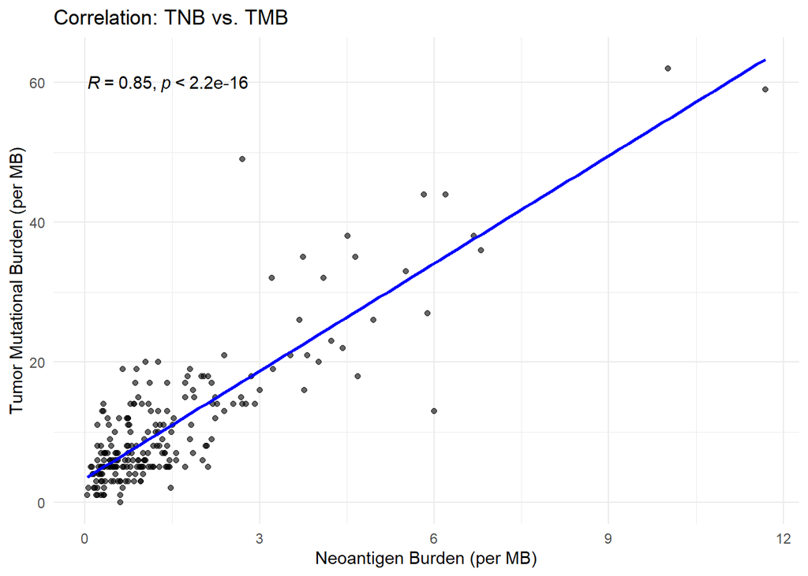

```r
p_tnb_tmb_corr <- ggplot(
  clinical_data,
  mapping = aes(
    x = Neoantigen.burden.per.MB,
    y = FMOne.mutation.burden.per.MB
  )
) +
  geom_point(alpha = 0.6) +
  geom_smooth(method = "lm", color = "blue", se = FALSE) +
  stat_cor(method = "pearson") +
  theme_minimal() +
  labs(
    title = "Correlation: TNB vs. TMB",
    x = "Neoantigen Burden (per MB)",
    y = "Tumor Mutational Burden (per MB)"
  )

print(p_tnb_tmb_corr)
```

```r
ggsave(
  filename = file.path(results_dir, "RQ5_correlation_TNB_vs_TMB.png"),
  plot = p_tnb_tmb_corr,
  width = 7,
  height = 5,
  dpi = 300
)
```

The scatter plot demonstrates a positive correlation between Tumor Neoantigen Burden (TNB) and Tumor Mutational Burden (TMB). However, while the Pearson correlation coefficient ($R = 0.85, p < 2.2e-16$) indicates a statistically significant relationship, the variance around the trendline - particularly among highly mutated samples - suggests they are not perfectly interchangeable metrics. Therefore, we will proceed with the survival analysis using both subsets independently to determine their distinct predictive values.

CR: Complete Response

PR: Partial Response

SD: Stable Disease

PD: Progressive Disease

We classify CR/PR as R (Responder) and PD/SD as NR (Non-Responder).

```r
clean_clinical <- clinical_data  |>
  filter(!is.na(binaryResponse)) |>
  mutate(Responder_Group = ifelse(binaryResponse %in% c("CR/PR"), "R", "NR"))

table(clean_clinical$Responder_Group)
```

```
 NR   R
230  68
```

```r
#Extract raw count matrix
count_matrix <- counts(cds)
```

```r
#Extract gene information
gene_info <- as.data.frame(rowData(cds))

rownames(count_matrix) <- make.unique(as.character(gene_info$symbol))
```

```r
cat("\nPFS status:\n")
```

```
PFS status:
```

```r
print(table(Event = clean_clinical$censOS))
```

```
Event
  0   1
109 189
```

```r
cat("\nResponse by PFS event status:\n")
```

```
Response by PFS event status:
```

```r
print(table(Response = clean_clinical$Responder_Group, PFS_event = clean_clinical$censOS))
```

```
        PFS_event
Response   0   1
      NR  46 184
      R   63   5
```

```r
print(colSums(is.na(clean_clinical[c("Responder_Group", "os", "censOS",
                                     "FMOne.mutation.burden.per.MB",
                                     "Neoantigen.burden.per.MB")])))
```

```
             Responder_Group                           os
                           0                            0
                      censOS FMOne.mutation.burden.per.MB
                           0                           64
    Neoantigen.burden.per.MB
                          82
```

We need some cleaning on the TMB variables.

```r
table(
  Missing_TMB = is.na(clean_clinical$FMOne.mutation.burden.per.MB),
  Missing_TNB = is.na(clean_clinical$Neoantigen.burden.per.MB)
)
```

```
           Missing_TNB
Missing_TMB FALSE TRUE
      FALSE   192   42
      TRUE     24   40
```

We can see that among all the samples, there are only 40 who have neither TNB nor TMB. It means that the NAs might result from technical differences, so the dataset must be adapted in regards with the undergoing analysis.

```r
clean_clinical_TMB <- clean_clinical[!is.na(clean_clinical["FMOne.mutation.burden.per.MB"]),]

clean_clinical_TNB <- clean_clinical[!is.na(clean_clinical["Neoantigen.burden.per.MB"]),]
```

### Helper functions

```r
# Convert a survdiff() chi-squared statistic to a p-value.
lr_p <- function(x) {
  pchisq(x$chisq, df = length(x$n) - 1, lower.tail = FALSE)
}

# Draw a Kaplan–Meier curve with confidence bands, a risk table, and p-value.
km_plot <- function(fit, title, p) {
  ggsurvfit(fit, linewidth = 1) +
    add_confidence_interval() +
    annotate(
      "text",
      x = Inf, y = Inf,
      label = paste0(
        "Log-rank p = ",
        format.pval(p, digits = 2, eps = 0.001)
      ),
      hjust = 1.1, vjust = 1.4
    ) +
    add_risktable(
      risktable_stats = c("n.risk", "cum.event"),
      stats_label = c("At risk", "Events")
    ) +
    scale_ggsurvfit() +
    labs(
      title = title,
      x = "Overall survival (months)",
      y = "Overall survival probability",
      color = "Group",
      fill = "Group"
    ) +
    theme_classic() +
    theme(legend.position = "bottom")
}
```

## TMB Survival Analysis

Several variable to check : PD vs SD, R vs NR, IC level, TMB, TC level, ….

### Whole cohort

Begin by inspecting TMB distribution to find a good cut-off point.

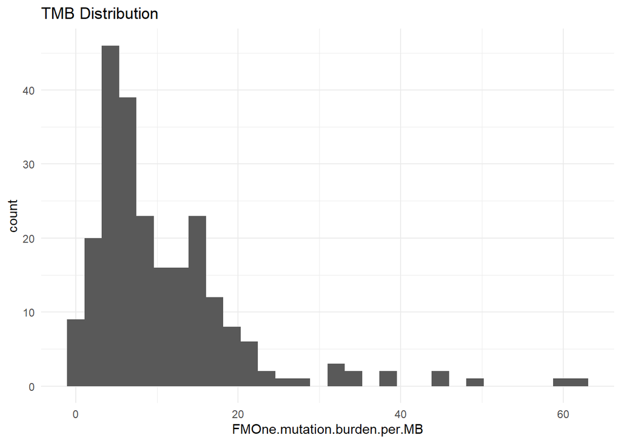

```r
p_tmb_dist <- ggplot(
  clean_clinical_TMB,
  aes(x = FMOne.mutation.burden.per.MB)
) +
  geom_histogram() +
  theme_minimal() +
  labs(title = "TMB Distribution")

print(p_tmb_dist)
```

```r
ggsave(
  filename = file.path(results_dir, "RQ5_distribution_TMB.png"),
  plot = p_tmb_dist,
  width = 7,
  height = 5,
  dpi = 300
)
```

Looks like a Negative binomiale distribution, thus taking median value would create imbalanced groups.

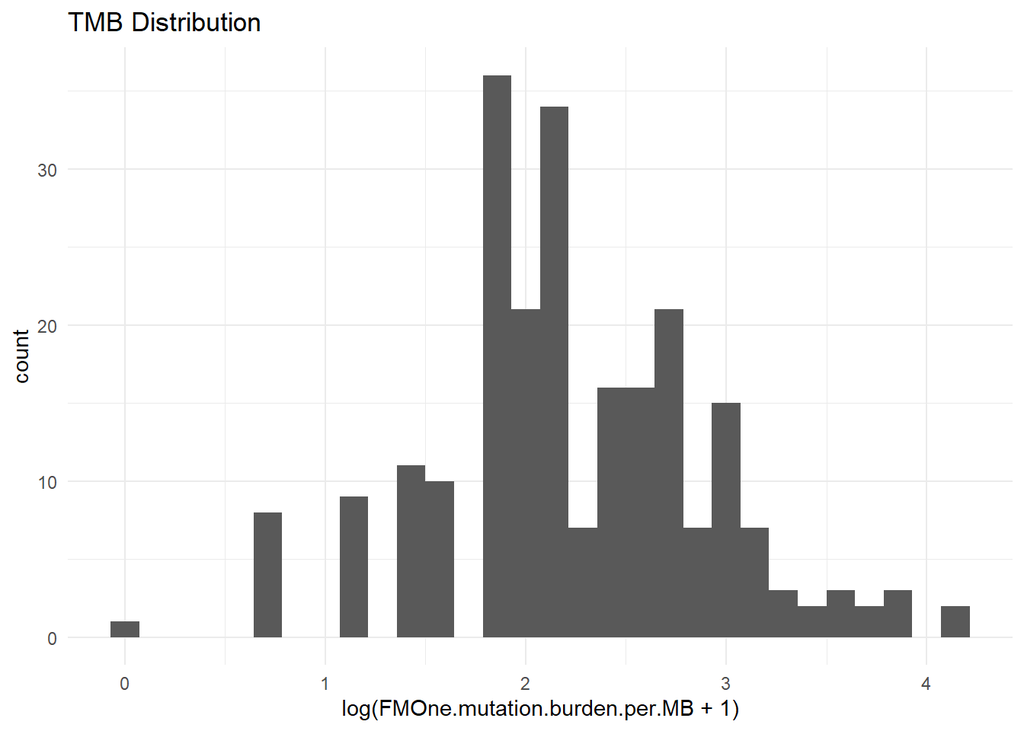

```r
p_tmb_log_dist <- ggplot(
  clean_clinical_TMB,
  aes(x = log(FMOne.mutation.burden.per.MB + 1))
) +
  geom_histogram() +
  theme_minimal() +
  labs(title = "TMB Distribution")

print(p_tmb_log_dist)
```

```r
ggsave(
  filename = file.path(results_dir, "RQ5_distribution_TMB_log.png"),
  plot = p_tmb_log_dist,
  width = 7,
  height = 5,
  dpi = 300
)
```

```r
# Find the optimal cutpoint for TMB against overall survival
cut_tmb <- surv_cutpoint(
  data = clean_clinical_TMB,
  time = "os",
  event = "censOS",
  variables = "FMOne.mutation.burden.per.MB",
  minprop = 0.1
)

summary(cut_tmb)
```

|  | cutpoint | statistic |
| --- | --- | --- |
| FMOne.mutation.burden.per.MB | 17 | 4.047374 |

```r
png(
  filename = file.path(results_dir, "RQ5_cutpoint_TMB.png"),
  width = 7,
  height = 5,
  units = "in",
  res = 300
)
plot(cut_tmb, "FMOne.mutation.burden.per.MB", palette = "npg")
```

```r
dev.off()
```